# Salary

Leo Lu

2016-09-21

本範例需要的套件

```r
library(magrittr)
library(readr)
library(readxl)
library(dplyr)
library(tidyr)
library(stringr)
library(lubridate)
library(ggplot2)
library(scales)
```

## 視覺化流程總結

1. **Issue**: 這張圖表想解決的問題是什麼？
2. **Geoms**: 要畫什麼樣的圖？
   - bar chart, line chart, heat map, …
3. **Variables**: 需要那些變數？我的資料有這些變數嗎？
   - variables needed from the data
4. **Aesthetic Mapping**
   - x:
   - y:
   - …

## Data Source

- [行政院主計總處-薪資及生產力統計資料](http://www.dgbas.gov.tw/ct.asp?xItem=1135&ctNode=3253)
- [行政院主計總處-消費者物價基本分類指數](http://win.dgbas.gov.tw/dgbas03/latestind-pca.asp?i=21)

## Import Dataset

```r
salary_df <- read_excel("data/salary_cpi/MoreTable01.xlsx")
## fix variable names
names(salary_df) <- names(salary_df) %>%
  make.names() %>%
  str_replace_all("(?:\\.)+", "_") %>%
  str_replace("_+$", "") %>%
  str_replace_all("_([^男女])", "\\1")

cpi_df <- read_csv("data/salary_cpi/PR0101A1Mc.csv",
                col_names = c("month", "CPI"),
                skip = 4,
                locale = locale(encoding = "BIG5")) %>% na.omit()
salary_df
```

```
#> # A tibble: 30,414 × 32
#>    時間月                   行業 受僱員工人數 受僱員工人數_男
#>     <chr>                  <chr>        <chr>           <chr>
#> 1    62/1       礦業及土石採取業        58568           50503
#> 2    62/1                 製造業      1402328          690213
#> 3    62/1       電力及燃氣供應業        14300           12799
#> 4    62/1                 營造業       100972           88181
#> 5    62/1           運輸及倉儲業       178446          150522
#> 6    62/1 鐵路大眾捷運系統運輸業        26588           25069
#> 7    62/1         公共汽車客運業        35630           23275
#> 8    62/1         其他汽車客運業         3262            2131
#> 9    62/1             汽車貨運業        49643           47451
#> 10   62/1             海洋水運業         6488            5958
#> # ... with 30,404 more rows, and 28 more variables: 受僱員工人數_女 <chr>,
#> #   每人每月薪資 <chr>, 每人每月薪資_男 <chr>, 每人每月薪資_女 <chr>,
#> #   經常性薪資 <chr>, 經常性薪資_男 <chr>, 經常性薪資_女 <chr>,
#> #   非經常性薪資 <chr>, 非經常性薪資_男 <chr>, 非經常性薪資_女 <chr>,
#> #   加班費 <chr>, 加班費_男 <chr>, 加班費_女 <chr>, 平均工時 <chr>,
#> #   平均工時_男 <chr>, 平均工時_女 <chr>, 正常工時 <chr>,
#> #   正常工時_男 <chr>, 正常工時_女 <chr>, 加班工時 <chr>,
#> #   加班工時_男 <chr>, 加班工時_女 <chr>, 進入率 <chr>, 退出率 <chr>,
#> #   勞動生產力指數 <chr>, 單位產出勞動成本指數 <chr>, 薪資指數 <chr>,
#> #   經常性薪資指數 <chr>
```

```r
cpi_df
```

```
#> # A tibble: 427 × 2
#>      month   CPI
#>      <chr> <dbl>
#> 1  1981M01 58.05
#> 2  1981M02 59.04
#> 3  1981M03 59.30
#> 4  1981M04 59.54
#> 5  1981M05 59.31
#> 6  1981M06 59.87
#> 7  1981M07 60.10
#> 8  1981M08 60.69
#> 9  1981M09 61.42
#> 10 1981M10 61.08
#> # ... with 417 more rows
```

## Data Cleansing

```r
# data type
salary_df <- salary_df %>%
  filter(!is.na(`時間月`)) %>% # 濾掉非資料列
  mutate_at(vars(matches("薪資|費|工時|率|數")), as.numeric) %>% # 轉成數值型
  mutate(行業 = factor(行業, levels = unique(行業)))  # 行業順序

# 月份資料
salary_df <- salary_df %>%
  separate(時間月, into = c("民國年", "月"), sep = "/") %>% # 先拆分年月
  mutate(年 = as.integer(民國年) + 1911) %>%                # 轉成西元年
  mutate(month = as.Date(paste(年, 月, "01", sep = "-"))) %>% # 轉換成日期
  select(-c(民國年, 月))  # 去掉中間計算用的變數
salary_df %>% select(month)
```

```
#> # A tibble: 30,413 × 1
#>         month
#>        <date>
#> 1  1973-01-01
#> 2  1973-01-01
#> 3  1973-01-01
#> 4  1973-01-01
#> 5  1973-01-01
#> 6  1973-01-01
#> 7  1973-01-01
#> 8  1973-01-01
#> 9  1973-01-01
#> 10 1973-01-01
#> # ... with 30,403 more rows
```

```r
# 移除重複資料
salary_df <- salary_df %>%
  distinct(month, 行業,.keep_all = TRUE)

cpi_df <- cpi_df %>%
  mutate(month = str_replace(month, "M", "-")) %>%
  mutate(month = paste(month, "01", sep = "-")) %>%
  mutate(month = as.Date(month))
cpi_df %>% select(month)
```

```
#> # A tibble: 427 × 1
#>         month
#>        <date>
#> 1  1981-01-01
#> 2  1981-02-01
#> 3  1981-03-01
#> 4  1981-04-01
#> 5  1981-05-01
#> 6  1981-06-01
#> 7  1981-07-01
#> 8  1981-08-01
#> 9  1981-09-01
#> 10 1981-10-01
#> # ... with 417 more rows
```

## 消費者物價指數 – 物價真的上漲嗎？

1. **Issue**: 想知道物價的歷史波動的情況
2. **Geoms**: bar chart, line chart, …
3. **Variables**: cpi, date (month)
4. **Aesthetic Mapping**
   - x: month
   - y: cpi

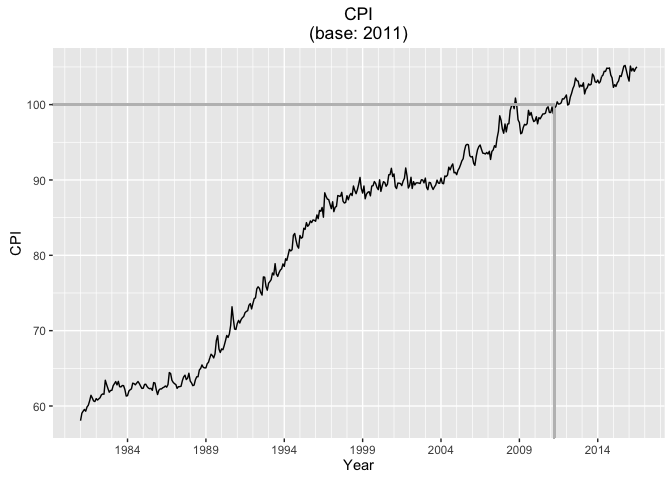

```r
# interpolation
base_date <- approx(cpi_df$CPI, cpi_df$month, xout = 100)$y %>%
  as.Date(origin = "1970-01-01")

ggplot(cpi_df) +
  geom_line(aes(x = month, y = CPI)) +
  geom_segment(x = 0,
               xend =  as.numeric(base_date),
               y = 100, yend = 100,
               color = "grey") +
  geom_segment(x = as.numeric(base_date),
               xend =  as.numeric(base_date),
               y = 0, yend = 100,
               color = "grey") +
  scale_x_date(name = "Year",
               date_breaks = "5 year",
               minor_breaks = scales::date_breaks("year"),
               date_labels = "%Y") +
  ggtitle("CPI\n(base: 2011)")
```

## 名目薪資

### 整體名目薪資

1. **Issue**: 想知道產業整體的薪資走勢
2. **Geoms**: bar chart, line chart, …
3. **Variables**: 經常性薪資, month
4. **Aesthetic Mapping**
   - x: month
   - y: mean_salary (手動計算)

```r
d <- salary_df %>%
  group_by(month) %>%
  summarise(mean_salary = mean(經常性薪資))
d
```

```
#> # A tibble: 521 × 2
#>         month mean_salary
#>        <date>       <dbl>
#> 1  1973-01-01    2890.750
#> 2  1973-02-01    2784.438
#> 3  1973-03-01    2881.812
#> 4  1973-04-01    2889.625
#> 5  1973-05-01    2912.500
#> 6  1973-06-01    2965.750
#> 7  1973-07-01    3047.188
#> 8  1973-08-01    3108.562
#> 9  1973-09-01    3117.812
#> 10 1973-10-01    3176.938
#> # ... with 511 more rows
```

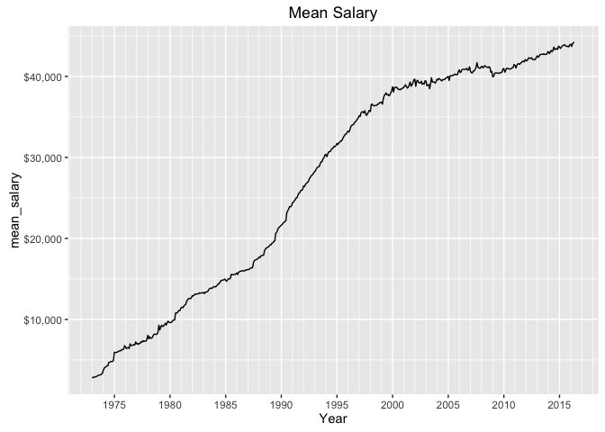

```r
ggplot(d) +
  geom_line(aes(x = month, y = mean_salary)) +
  scale_x_date(name = "Year",
               date_breaks = "5 year",
               minor_breaks = scales::date_breaks("year"),
               date_labels = "%Y") +
  scale_y_continuous(labels = scales::dollar) +
  ggtitle("Mean Salary")
```

### 各行業名目薪資

1. **Issue**: 各行業名目薪資走勢
2. **Geoms**: bar chart, line chart, …
3. **Variables**: 行業, 經常性薪資, month
4. **Aesthetic Mapping**
   - x: month
   - y: 經常性薪資
   - facet: 行業

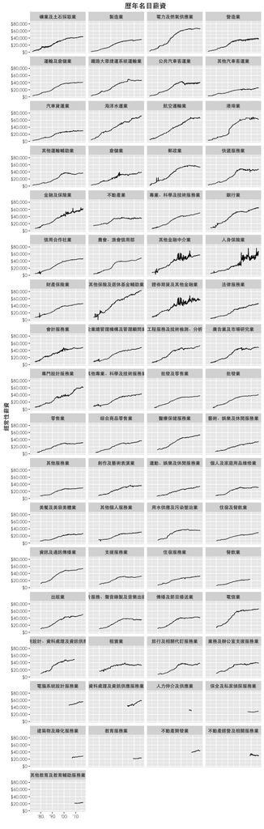

```r
ggplot(salary_df) +
  geom_line(aes(x = month, y = 經常性薪資)) +
  facet_wrap(~ 行業, ncol = 4) +
  scale_x_date(name = "", date_breaks = "10 year", date_labels = "'%y") +
  scale_y_continuous(labels = scales::dollar) +
  labs(title = "歷年名目薪資",
       subtitle = "各行業平均薪資, $", xlab = "") +
  theme(text = element_text(family = "STHeiti")) # Mac font
```

### 現今各行業名目薪資排名

1. **Issue**: 那個行業薪水最高呢？
2. **Geoms**: bar chart
3. **Variables**: 行業, 經常性薪資
4. **Aesthetic Mapping**
   - x: 行業
   - y: 經常性薪資 (最近一期)

```r
# 最近一期的統計時間
(last_date <- salary_df %>%
  select(month) %>%
  .[[1]] %>%
  max(na.rm = TRUE))
```

```
#> [1] "2016-05-01"
```

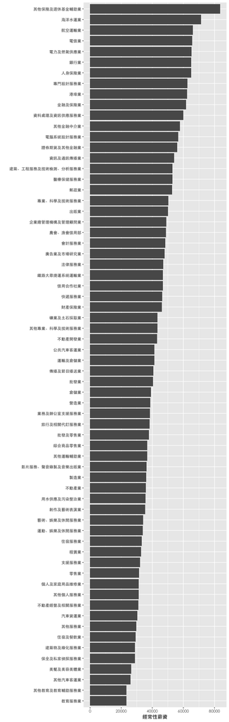

```r
# 篩選最近一期的資料
d <- salary_df %>%
  filter(month == last_date)

ggplot(d) +
  geom_bar(aes(x=reorder(行業, 經常性薪資), y=經常性薪資),
           stat = "identity") +
  xlab("") +
  coord_flip() +
  theme(text = element_text(family = "STHeiti")) # Mac font
```

## 實質薪資

[實質薪資如何計算？](http://www.dgbas.gov.tw/ct.asp?xItem=815&ctNode=2332)

實質薪資＝ (計算期之名目薪資 / 計算期消費者物價指數) * 100

### 整體情況

```r
d <- salary_df %>%
  left_join(cpi_df, by = "month") %>%     # 合併 CPI 資料
  mutate(real_wage = 經常性薪資 / CPI * 100) %>%  # 計算實質薪資
  group_by(month) %>%
  summarise(mean_real_wage = mean(real_wage))
d
```

```
#> # A tibble: 521 × 2
#>         month mean_real_wage
#>        <date>          <dbl>
#> 1  1973-01-01             NA
#> 2  1973-02-01             NA
#> 3  1973-03-01             NA
#> 4  1973-04-01             NA
#> 5  1973-05-01             NA
#> 6  1973-06-01             NA
#> 7  1973-07-01             NA
#> 8  1973-08-01             NA
#> 9  1973-09-01             NA
#> 10 1973-10-01             NA
#> # ... with 511 more rows
```

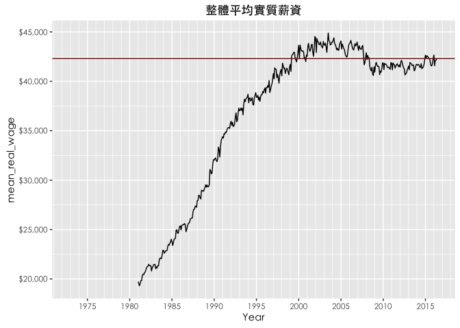

```r
ggplot(d) +
  geom_line(aes(x = month, y = mean_real_wage)) +
  scale_x_date(name = "Year",
               date_breaks = "5 year",
               minor_breaks = scales::date_breaks("year"),
               date_labels = "%Y") +
  scale_y_continuous(labels = scales::dollar) +
  geom_hline(yintercept = max(d %>%
                                filter(month == max(month)) %>%
                                .[["mean_real_wage"]],
                              na.rm = TRUE),
             color = "darkred") +
  ggtitle("整體平均實質薪資") +
  theme(text = element_text(family = "STHeiti")) # Mac font
```

### 行業別

```r
d <- salary_df %>%
  left_join(cpi_df, by = "month") %>%  # 合併 CPI 資料
  mutate(real_wage = 經常性薪資 / CPI * 100)  # 計算實質薪資
# 計算個行業最近一期薪資以畫線
d_now <- d %>%
  select(行業, month, real_wage) %>%
  group_by(行業) %>%
  filter(month == max(month, na.rm = TRUE))
d_now
```

```
#> Source: local data frame [69 x 3]
#> Groups: 行業 [69]
#>
#>                                      行業      month real_wage
#>                                    <fctr>     <date>     <dbl>
#> 1                                  餐飲業 2008-12-01  23437.09
#> 2  電腦系統設計、資料處理及資訊供應服務業 2008-12-01  50620.47
#> 3                        人力仲介及供應業 2008-12-01  32283.91
#> 4                        礦業及土石採取業 2016-05-01  41536.10
#> 5                                  製造業 2016-05-01  34638.00
#> 6                        電力及燃氣供應業 2016-05-01  62461.21
#> 7                    用水供應及污染整治業 2016-05-01  34122.77
#> 8                                  營造業 2016-05-01  37139.44
#> 9                            批發及零售業 2016-05-01  36227.73
#> 10                           運輸及倉儲業 2016-05-01  39596.82
#> # ... with 59 more rows
```

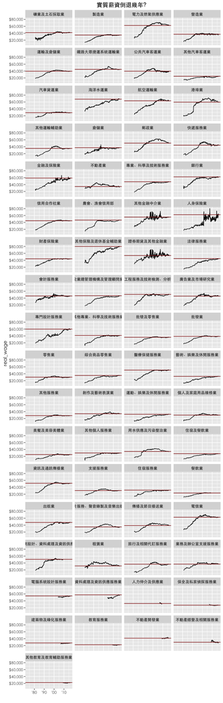

```r
p <- ggplot(d) +
  geom_line(aes(x = month, y = real_wage)) +
  scale_x_date(name = "", date_breaks = "10 year", date_labels = "'%y") +
  scale_y_continuous(labels = scales::dollar) +
  geom_hline(data = d_now,
             aes(yintercept = real_wage),
             color = "darkred") +
  facet_wrap(~ 行業, ncol = 4) +
  labs(title = "實質薪資倒退幾年？",
       subtitle = "各行業平均實質薪資, $",
       caption = "資料來源: \n
                  行政院主計總處-薪資及生產力統計資料\n
                  行政院主計總處-消費者物價基本分類指數") +
  theme(text = element_text(family = "STHeiti")) # Mac font
plot(p)
```

## Reference

- [勞動部工資工時統計名詞](http://statdb.mol.gov.tw/html/com/st0302.htm)
- http://www.moneynet.com.tw/woman_2.php?i=1880